# ST405/ST645 Bayesian Data Analysis

Assignment 3: Football outcomes vs point spread

Author

Prof. Niamh Cahill

## Instructions

Please submit your answers to this assignment by **November 26th, 4:00PM**. Include your JAGS model with your answers.

### Dataset

Football experts provide a point spread for every football game as a measure of the difference in ability between the two teams. A dataset of actual outcome vs. point spread for each of 672 professional football games is provided (available on the Rstudio server). Each observation contains `spread`, x, and the outcome (favorite’s score minus underdog’s score), y. A plot of the data is shown below.

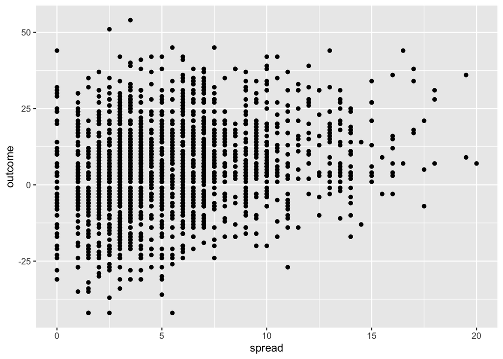

```r
p <- ggplot(football_dat, aes(x=spread, y=outcome)) +
  geom_point()
p
```

### Analysis

Use JAGS to fit a linear regression model for outcome (y) as a function of point spread (x) but where the residual variance is also modeled as a function of the point spread (x) such that

$y_i|\mu,\sigma^2 \sim Normal(\mu_i, \sigma_i^2)$,

$\mu_i = \alpha + \beta x_i$,

$\sigma_i = exp(\alpha_{\sigma} + \beta_{\sigma} x_i)$.

Assume Normal(0,10^2) priors for $\alpha$, $\beta$, $\alpha_{\sigma}$ and $\beta_{\sigma}$

This is a *heteroscedastic* linear regression, where

1. The expected value of $y$ (outcome) for each data point $i$ is modeled with a standard linear regression describing how the mean outcome changes with the point spread.
2. The variance of $y$ for each data point $i$ isn’t constant but changes with $x$. The log-linear formulation for $\sigma_i$ (the standard deviation of the outcome) ensures that $\sigma_i$ remains positive, which is necessary for valid variance. In the specification $\alpha_{\sigma}$ and $\beta_{\sigma}$ are parameters governing how the residual standard deviation varies with $x$.

By fitting both the mean and variance as functions of $x$ in the regression model, the model can capture two relationships:

- The effect of the point spread on the average outcome.
- The effect of the point spread on the variability of the outcome, potentially showing less variability in outcome values as the point spread grows.

### Questions **[Total = 35 Marks]**

Based on this model, complete tasks 1 - 4 below.

- **Task 1: Model Fitting and Parameter Estimation**

**[8 Marks]** Write the JAGS code and run the model to provide parameter summaries (medians and 95% credible intervals) for $\alpha$, $\beta$, $\alpha_{\sigma}$ and $\beta_{\sigma}$.

- **Task 2: Inference**

Based on your parameter estimates,

1. **[2 Marks]** does there appear to be a relationship between the outcome ($y$) and the point spread? Explain your answer.
2. **[3 Marks]** does there appear to be a relationship between the residual variation ($\sigma_i$) and the point spread? Explain your answer.
- **Task 3: Posterior Predictive Checking**

**[3 Marks]** Modify your JAGS code to create simulated datasets, `yrep`, used for posterior predictive checking. Then,

1. **[3 Marks]** produce a PPC plot using `ppc_stat()` to compare the distribution of minimums from `yrep` with the observed minimum from `y`;
2. **[4 Marks]** produce a PPC plot using a PPC function called `ppc_intervals()`, which allows you to look at medians and uncertainty intervals for `yrep` vs a predictor variable, $x$ (use `?ppc_intervals()` to help);
3. **[5 Marks]** briefly explain what you have learned from these PPC plots.
- **Task 4: Additional Analysis**

**[7 Marks]** What is the median estimate and 95% prediction interval for an outcome when the point spread is 16?